# Transaktionsanalyse

Anna & René

02. März 2020

# 1 Beschreibung des verwendeten Datensatzes

Die nachfolgende Analyse beruht auf einem E-Commerce Datensatz, bereitgestellt durch das Center of Machine Learning and Intelligent Systems, abrufbar unter folgendem Link: https://archive.ics.uci.edu/ml/datasets/online+retail#

Die Daten beziehen sich auf einen Online Händler, der in UK ansässig ist und eine breite Palette verschiedenster Geschenk- und Dekoartikel vertreibt. Der Datensatz beinhaltet dabei Bestellungen aus einer Vielzahl an Ländern. Die vorliegende Analyse wurde auf Bestellungen aus UK beschränkt.

Anzahl der Kunden: 3921

Anzahl der Bestellungen: 349203

# 2 Kunden

Dabei wurden **durchschnittlich pro Kunde 89.082398 Bestellungen** getätigt, allerdings zeigen die Daten, dass unter den Kunden mindestens einer ist, der 7676 Bestellungen getätigt hat. Damit dieser Ausreißer nicht so stark ins Gewicht fällt, betrachten wir zustäzlich den Median, dieser liegt bei 40. Ausgelöst wurde dabei ein **durchschnittlicher Kundenumsatz von 1858.4246541**, der Median liegt hier bei 644.975.

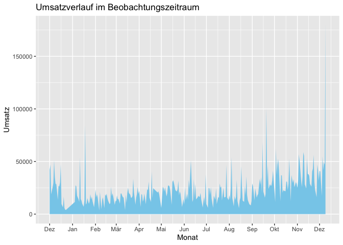

## 2.1 Übersicht Bestellungen

| weekday | anzahl_bestellungen | revenue | bestellwert |
| --- | --- | --- | --- |
| Do | 3599 | 1563033.2 | 434.2965 |
| Mi | 3091 | 1276826.6 | 413.0788 |
| Di | 2887 | 1415789.0 | 490.4014 |
| Mo | 2553 | 1126022.2 | 441.0584 |
| Fr | 2478 | 1215510.0 | 490.5206 |
| So | 2038 | 687843.7 | 337.5092 |

Produkte mit höchstem Umsatz

| Description | anzahl | unit_price | revenue |
| --- | --- | --- | --- |
| REGENCY CAKESTAND 3 TIER | 1417 | 12.517290 | 17737.00 |
| Manual | 243 | 67.844321 | 16486.17 |
| DOTCOM POSTAGE | 16 | 744.147500 | 11906.36 |
| POSTAGE | 27 | 319.222963 | 8619.02 |
| PARTY BUNTING | 1300 | 4.880785 | 6345.02 |
| WHITE HANGING HEART T-LIGHT HOLDER | 1929 | 2.894127 | 5582.77 |
| CREAM SWEETHEART MINI CHEST | 425 | 12.645553 | 5374.36 |
| VINTAGE RED KITCHEN CABINET | 35 | 145.000000 | 5075.00 |
| SET OF 3 CAKE TINS PANTRY DESIGN | 1013 | 4.965192 | 5029.74 |
| DOORMAT KEEP CALM AND COME IN | 620 | 7.914694 | 4907.11 |

Betrachten wir den Absatz der Produkte, war das absatzstärkste Produkt **WHITE HANGING HEART T-LIGHT HOLDER** mit einer Anzahl von **1929 Stück**, dieses war bei der Umsatz-Betrachtung zuvor auf Platz sechs mit 5582.77 Umsatz . Gefolgt von **JUMBO BAG RED RETROSPOT** (1461 Stück) und **REGENCY CAKESTAND 3 TIER** (1417 Stück).

Produkte mit höchstem Absatz

| Description | anzahl | unit_price | revenue |
| --- | --- | --- | --- |
| WHITE HANGING HEART T-LIGHT HOLDER | 1929 | 2.894127 | 5582.77 |
| JUMBO BAG RED RETROSPOT | 1461 | 2.016393 | 2945.95 |
| REGENCY CAKESTAND 3 TIER | 1417 | 12.517290 | 17737.00 |
| ASSORTED COLOUR BIRD ORNAMENT | 1320 | 1.681455 | 2219.52 |
| PARTY BUNTING | 1300 | 4.880785 | 6345.02 |
| LUNCH BAG RED RETROSPOT | 1135 | 1.663568 | 1888.15 |
| LUNCH BAG BLACK SKULL. | 1022 | 1.644716 | 1680.90 |
| SET OF 3 CAKE TINS PANTRY DESIGN | 1013 | 4.965192 | 5029.74 |
| PAPER CHAIN KIT 50’S CHRISTMAS | 967 | 2.938997 | 2842.01 |
| HEART OF WICKER SMALL | 946 | 1.639482 | 1550.95 |

Berücksichtigen wir die Ergebnisse aus der Umsatz-Analyse zuvor und den Absatz, sehen wir, dass die Produkte **REGENCY CAKESTAND 3 TIER** und **PARTY BUNTING** bei beiden sehr gut abschneiden. **REGENCY CAKESTAND 3 TIER** ist dabei das teuerste Produkt mit einem Einzel-Kaufpreis von **12.51729 Pfund**. Wie zuvor schon erwähnt zeigt auch das Produkt **WHITE HANGING HEART T-LIGHT HOLDER** bei Umsatz und Absatz jeweils gute Werte.

## 2.2 Bestellungen vor zeitlichem Hintergrund

Betrachten wir die Bestellungen nach Wochentagen, fällt auf, dass die **meisten Bestellungen (3599) am Donnerstag** erfolgen, Samstags gingen allerdings gar keine Bestellungen ein. Schauen wir uns die Tageszeit an zu der die Bestellungen gesamt erfolgten, sehen wir, dass über alle Tage verteilt am meisten Bestellungen (2866) in **Stunde 12** erfolgen.

Schauen wir uns die Bestellzeit für jeden Tag einzeln an, dann sehen wir, dass an allen Tagen die meisten Bestellungen in Stunde 12 eingehen. Außerdem sehen wir, dass donnerstags vergleichsweise länger bestellt wird.

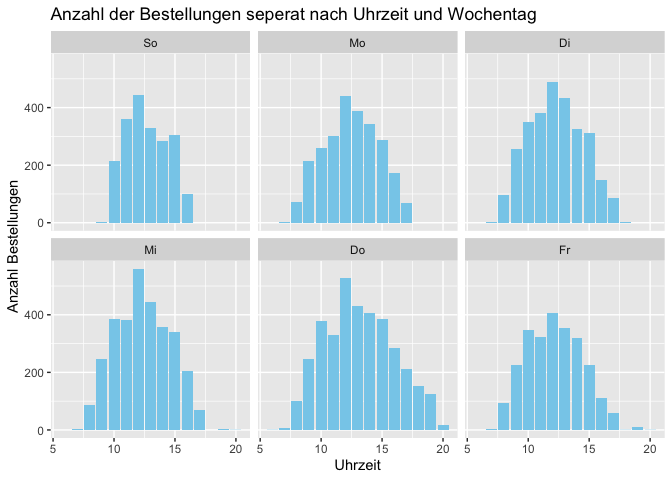

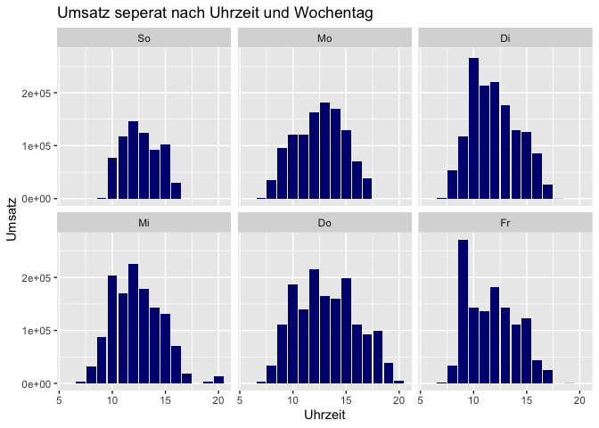

# 3 Preis-Analyse

| Country | mittelwert_produktpreis | median_produktpreis | min_produktpreis | max_produktpreis |
| --- | --- | --- | --- | --- |
| United Kingdom | 2.972328 | 1.95 | 0.001 | 8142.75 |

```r
# ABC Analyse
```

# 4 Warenkorbanalyse (Apriori-Analyse)

## 4.1 Libraries und Daten laden

Die Daten wurden auf einen Produktpreis von größer als 5 Pfund gefilter, um sich auf Regeln zu fokusieren, hinter denen ein gewisser Umsatz steht.

## 4.2 Daten visualisieren

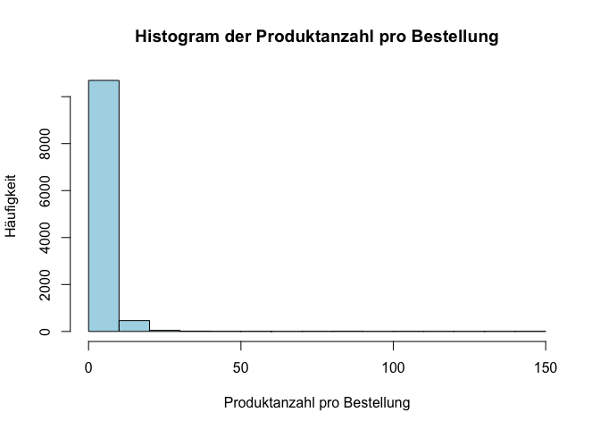

Aus dem Histogram geht hervor, dass der Großteil der Bestellungen maximal 10 verschiedene Artikel enthält. Betracht man den folgenden Boxplot, so werden die Ausreißer noch einmal deutlich. @Jörn: Sollten diese rausgefiltert werden, da sie die Analyse verzerren?

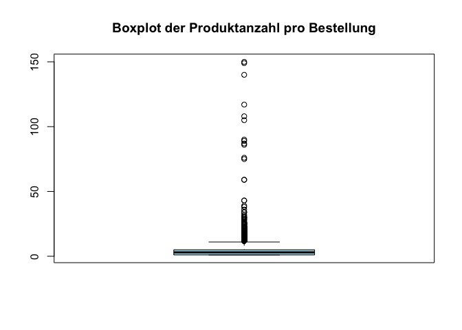

[output not shown]

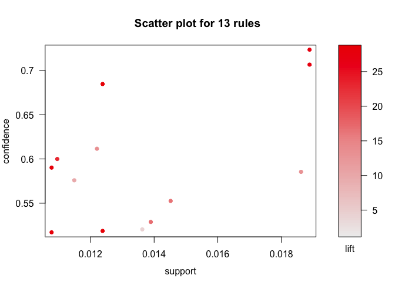

Ziel ist es Regeln zu finden, die möglichst weit oben rechts und in dunkelrot gefärbt sind, da diese einen hohen Support, Confidence und Lift aufweisen.

- Support = Signifikanzmaß der Regel (wie oft kommt die gefundene Regel in den Daten vor).
- Confidence = Wenn X gekauft wird, dann wird zu X % auch Y gekauft.
- Lift = 3 = Kauf von X verdreifacht die Wahrscheinlichkeit für Y.

## 4.3 Regeln darstellen und interpretieren

```r
summary(regeln)
```

```
## set of 13 rules
##
## rule length distribution (lhs + rhs):sizes
##  2
## 13
##
##    Min. 1st Qu.  Median    Mean 3rd Qu.    Max.
##       2       2       2       2       2       2
##
## summary of quality measures:
##     support          confidence          lift            count
##  Min.   :0.01078   Min.   :0.5171   Min.   : 4.153   Min.   :121.0
##  1st Qu.:0.01149   1st Qu.:0.5288   1st Qu.:13.385   1st Qu.:129.0
##  Median :0.01238   Median :0.5854   Median :22.681   Median :139.0
##  Mean   :0.01380   Mean   :0.5935   Mean   :20.313   Mean   :154.9
##  3rd Qu.:0.01452   3rd Qu.:0.6116   3rd Qu.:28.319   3rd Qu.:163.0
##  Max.   :0.01888   Max.   :0.7235   Max.   :28.685   Max.   :212.0
##
## mining info:
##               data ntransactions support confidence
##  transaktionsdaten         11227    0.01        0.5
```

```r
inspect(sort(regeln, by = "lift"))
```

```
##      lhs                                   rhs                                   support confidence      lift count
## [1]  {VINTAGE CREAM CAT FOOD CONTAINER} => {VINTAGE CREAM DOG FOOD CONTAINER} 0.01238087  0.6847291 28.684527   139
## [2]  {VINTAGE CREAM DOG FOOD CONTAINER} => {VINTAGE CREAM CAT FOOD CONTAINER} 0.01238087  0.5186567 28.684527   139
## [3]  {RED RETROSPOT UMBRELLA}           => {BLACK/BLUE POLKADOT UMBRELLA}     0.01077759  0.5170940 28.319095   121
## [4]  {BLACK/BLUE POLKADOT UMBRELLA}     => {RED RETROSPOT UMBRELLA}           0.01077759  0.5902439 28.319095   121
## [5]  {PINK HAPPY BIRTHDAY BUNTING}      => {BLUE HAPPY BIRTHDAY BUNTING}      0.01888305  0.7066667 27.077634   212
## [6]  {BLUE HAPPY BIRTHDAY BUNTING}      => {PINK HAPPY BIRTHDAY BUNTING}      0.01888305  0.7235495 27.077634   212
## [7]  {EDWARDIAN PARASOL BLACK}          => {EDWARDIAN PARASOL NATURAL}        0.01095573  0.6000000 22.680808   123
## [8]  {BLUE DINER WALL CLOCK}            => {IVORY DINER WALL CLOCK}           0.01389507  0.5288136 16.630224   156
## [9]  {BLUE DINER WALL CLOCK}            => {RED DINER WALL CLOCK}             0.01451857  0.5525424 16.498386   163
## [10] {MINT KITCHEN SCALES}              => {IVORY KITCHEN SCALES}             0.01220273  0.6116071 13.385016   137
## [11] {RED KITCHEN SCALES}               => {IVORY KITCHEN SCALES}             0.01861584  0.5854342 12.812221   209
## [12] {BATH BUILDING BLOCK WORD}         => {HOME BUILDING BLOCK WORD}         0.01149016  0.5758929  9.751959   129
## [13] {REGENCY TEAPOT ROSES}             => {REGENCY CAKESTAND 3 TIER}         0.01362786  0.5204082  4.152539   153
```

Bisher sind die Regeln relativ offensichtlich (wenn Farbe X gekauft wird, dann auch Farbe Y). @Jörn: Hast du einen Tipp wie wir die Qualität der Regeln verbessern könnten, so dass nicht nur sehr offensichtliche Dinge zum Vorschein kommen.